# Inverkehrsetzungen von Personenkraftwagen in der Schweiz

Markus Ilg

markus.ilg@markus-ilg.at

Begleitendes Beispiel zum Aufsatz  
Ilg, Markus; Baumeister, Alexander (2019): *Business Analytics im Marketing-Controlling - Eine Anwendungsfallstudie für den Automobildmarkt* in: Digitalisierung im Controlling. Hrsg. v. Keimer, I. und Egle U., S. xxx-yyy, Berlin: Springer.

Daten: Schweizerische Eidgenossenschaft - Bundesamt für Statistik.  
Abgerufen aus STAT-TAB am 24.8.2019:  
https://www.pxweb.bfs.admin.ch/pxweb/de/px-x-1103020200_120/-/px-x-1103020200_120.px

### Datenaufbereitung

Die Daten wurden aus STAT-TAB als csv-Datei exportiert. Die csv-Datei wird eingelesen und vom wide- ins long-Format konvertiert. Eine erste Darstellung der Daten zeigt einen möglichen Ausreißer im Juni 2012.

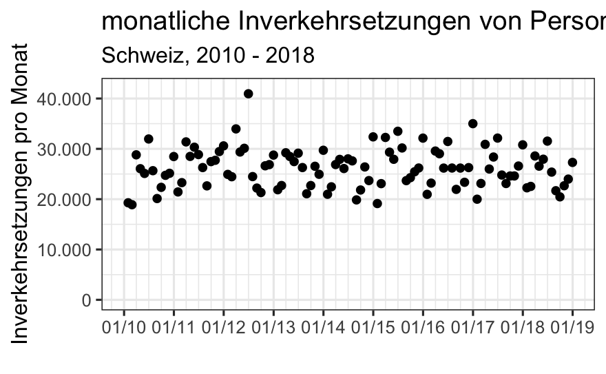

Die Recherche zeigt, dass der Peak durch eine Änderung der CO2-Emissionsvorschriften ab Juli 2012 verursacht wurde (https://www.bfs.admin.ch/bfs/de/home/dienstleistungen/fuer-medienschaffende/medienmitteilungen.assetdetail.36344.html).

Die Daten werden in einen Trainings- (bis Ende 2017) und einen Testbereich (ab 2018) getrennt. Die Daten im Testbereich werden nicht zur Schätzung, sondern zur Validierung des Modells verwendet. Die Daten des Testbereichs werden in blauer Farbe dargestellt.

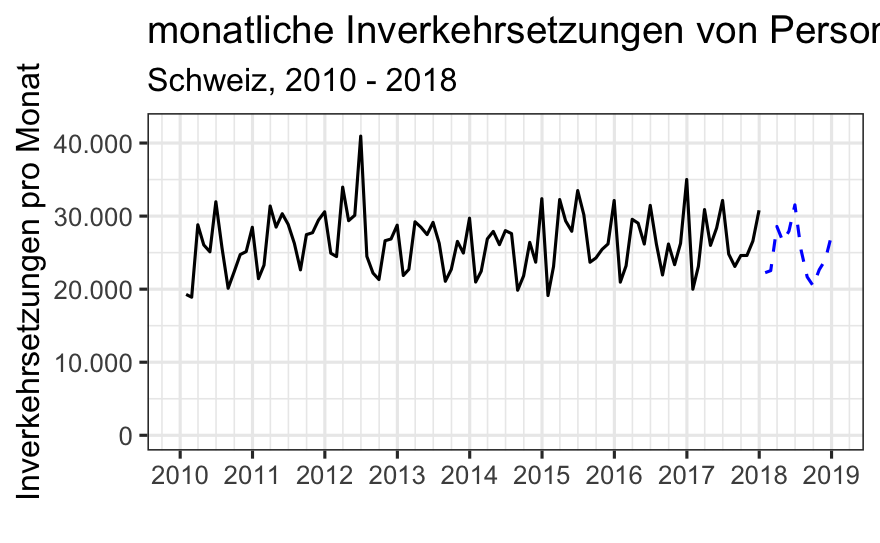

### Modellierung

#### Lineares Grundmodell

Zur Modellierung der Monate werden die Monatsbezeichnungen in zweistellige Zeichenketten transformiert (“01” bis “12”). `R` erzeugt daraus automatisch 11 Dummyvariablen zur Abbildung der Monate im Modell.

```
Call:
lm(formula = IVS ~ Datum + Monat, data = ivs_simple_train)

Residuals:
    Min      1Q  Median      3Q     Max
-4019.6 -1283.5   -37.4   903.5  9032.7

Coefficients:
             Estimate Std. Error t value Pr(>|t|)
(Intercept) 1.852e+04  4.138e+03   4.475 2.41e-05 ***
Datum       1.606e-01  2.557e-01   0.628   0.5317
Monat02     1.576e+03  1.049e+03   1.503   0.1367
Monat03     9.291e+03  1.049e+03   8.860 1.25e-13 ***
Monat04     6.998e+03  1.049e+03   6.672 2.64e-09 ***
Monat05     6.607e+03  1.049e+03   6.298 1.37e-08 ***
Monat06     1.091e+04  1.049e+03  10.395  < 2e-16 ***
Monat07     5.334e+03  1.050e+03   5.082 2.27e-06 ***
Monat08     7.254e+02  1.050e+03   0.691   0.4916
Monat09     2.729e+03  1.050e+03   2.598   0.0111 *
Monat10     4.566e+03  1.051e+03   4.345 3.92e-05 ***
Monat11     5.025e+03  1.051e+03   4.779 7.52e-06 ***
Monat12     9.856e+03  1.052e+03   9.369 1.19e-14 ***
---
Signif. codes:  0 ‘***’ 0.001 ‘**’ 0.01 ‘*’ 0.05 ‘.’ 0.1 ‘ ’ 1

Residual standard error: 2097 on 83 degrees of freedom
Multiple R-squared:  0.7585,    Adjusted R-squared:  0.7236
F-statistic: 21.73 on 12 and 83 DF,  p-value: < 2.2e-16
```

Der Anteil der erklärten Varianz beträgt über 75 Prozent. Die meisten der Saision-Dummies haben statistisch signifikante Koeffizienten, gleiches gilt für das Modell im Gesamten (vgl. F-Statistik).

#### Prüfung der Modellierungsvoraussetzungen

Wir prüfen die Modellierungsvoraussetzungen analog zu [Backhaus et al. (2018)](https://www.springer.com/de/book/9783662566541), S. 98 ff).

1. Nichtlinearität: die graphische Darstellung lässt - unter Berücksichtigung der Saisonkomponente vermuten, dass kein nennenswerter linearer Trend besteht.
2. Erwartungswert der Störgröße = 0: ist nicht von Bedeuutung, wirkt sich ggf. auf den Koeffizienten b0 aus.
3. Falsche Regressorenauswahl: Multikollinearität falsch spezifizierter Regressoren verzerrt die Parmeterschätzer, bei fehlender Multikollinearität wirken sie sich zumindest wieder auf den Ordinatenabschnitt b0 aus. Mit $Datum$ und $Monat$ sind hier allerdings keine überflüssigen Regressoren erkennbar.
4. Heteroskedastizität: Der Plot der Residuen gegen die erklärte Variable lässt keine für Heteroskedastizität typischen Verläufe erkennen.

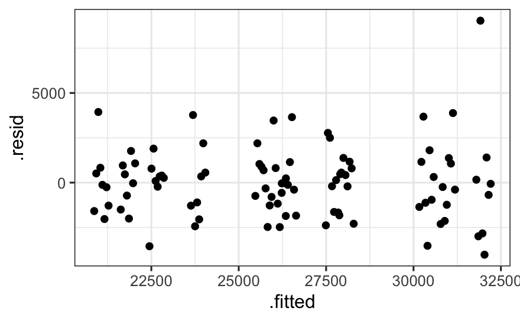

Heteroskedastizität kann auch mit dem Goldfeld-Quandt-Test überprüft werden. Die Nullhypothese (Homoskedastizität) kann nicht verworfen werden.

```
    Goldfeld-Quandt test

data:  mod
GQ = 0.46144, df1 = 35, df2 = 35, p-value = 0.9876
alternative hypothesis: variance increases from segment 1 to 2
```

5. Autokorrelation: Inbesondere bei Zeitreihen besteht die Gefahr der Verzerrung des Standardfehlers der Regressionskoeffizienten durch autokorrelierte Residuen. Im Ergebnis ergeben sich dann verzerrte Konfidenzintervalle für die Regressionskoeffizienten. Eine visuelle Prüfung erfolgt wie bei der Heterskedastizität im Plot der Residuen gegen die geschätzen Werte. Ebenso ist die Prüfung mit Durbin-Watson-Test möglich, dessen Nullhypothese (keine Autokorrelation) nicht verworfen werden kann.

```
    Durbin-Watson test

data:  mod
DW = 1.7108, p-value = 0.08825
alternative hypothesis: true autocorrelation is greater than 0
```

6. Multikollinearität: Schätzungen für Regressionskoeffizienten werden unzuverlässiger, wenn sich die Koeffizenten aus anderen Modellkoeffizienten errechnen lassen. Paarweise Multikollinearität ist vorhanden, wenn der Betrag der paarweisen Korrelationen nahe 1 ist. Abhängigkeiten von mehreren anderen Variablen kann durch die Toleranz oder deren Kehrwert, den Varianz-Inflation-Factor (VIF) ermittelt werden. VIF-Werte im bereich von 10 oder größer sind auf jeden Fall problematisch. Im Beispiel ist die Multikollinearität mit Datum bzw. Monat als Regressoren nicht relevant.

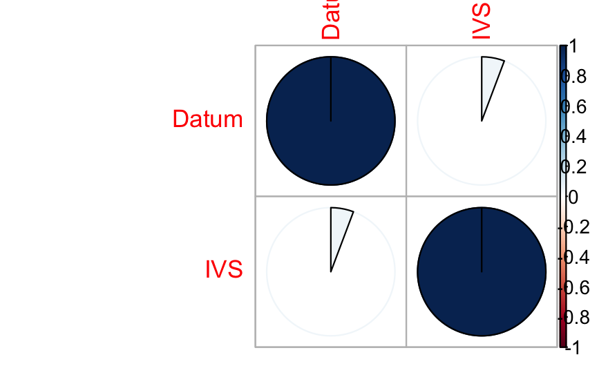

```
          GVIF Df GVIF^(1/(2*Df))
Datum 1.015821  1        1.007879
Monat 1.015821 11        1.000714
```

7. Normalverteilung der Residuen: Bei großer Stichprobe ist eine Abweichung von der Normalverteilungsannahme nicht so tragisch. Der QQ-Plot sieht allerdings nicht perfekt aus.

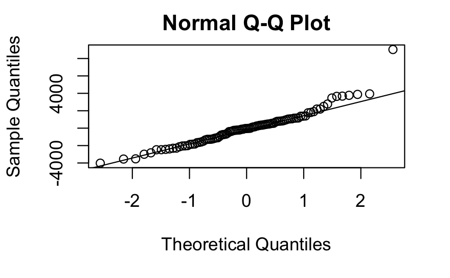

### Erstellung von Prognosen

Das berechnete Modell erlaubt die Berechnung von Prognosewerten. Durch den Vergleich der Prognosewerte für die Testdaten mit den Ist-Werten der Testdaten (2018) können Performance-Maße berechnet werden, die den Vergleich unterschiedlicher Modelle erlauben.

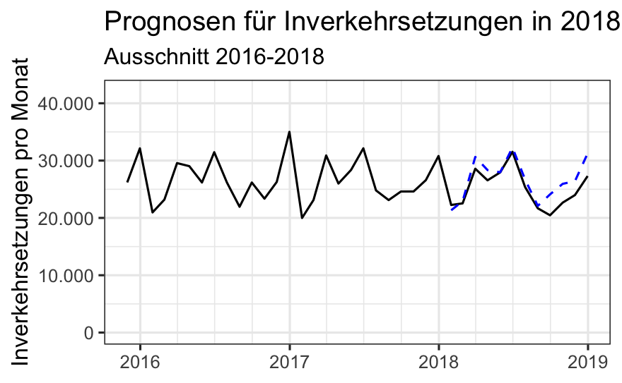

| mae | mape | mse | rmse |
| --- | --- | --- | --- |
| 1743.144 | 0.07172005 | 4691296 | 2165.94 |

### Alternative Modellierung über Quartale?

Die Modellierung der einzelnen Monate im Modell impliziert neben dem Datum weitere 11 Dummyvariablen. Es stellt sich die Frage, ob es nicht ein einfacheres Modell gibt. Ein Ansatzpunkt wäre statt Monaten Dummyvariablen für Quartale zu verwenden.

```
Call:
lm(formula = IVS ~ Datum + Quartal, data = ivs_simple_train)

Residuals:
    Min      1Q  Median      3Q     Max
-5682.3 -2272.0  -792.4  2012.7 11798.2

Coefficients:
              Estimate Std. Error t value Pr(>|t|)
(Intercept) 21231.2020  6713.5631   3.162  0.00213 **
Datum           0.2174     0.4187   0.519  0.60481
Quartal2     4542.9774   992.3030   4.578 1.48e-05 ***
Quartal3     -703.0670   994.5230  -0.707  0.48141
Quartal4     2844.4611   998.2094   2.850  0.00541 **
---
Signif. codes:  0 ‘***’ 0.001 ‘**’ 0.01 ‘*’ 0.05 ‘.’ 0.1 ‘ ’ 1

Residual standard error: 3435 on 91 degrees of freedom
Multiple R-squared:  0.2898,    Adjusted R-squared:  0.2586
F-statistic: 9.282 on 4 and 91 DF,  p-value: 2.456e-06
```

Der Erklärungsgehalt ist jedoch vernachlässigbar, das Saisonverhalten der IVS ist nicht über Quartale abbildbar, nur ca. 29 % der Varianz werden über das Quartalmodell erklärt.

### Test einer alternative Modellierung als ARIMA

Ein Alternative könnte die Betrachtung des Umsätze als ARIMA-Prozess sein. ARIMA steht für Autoregressive Intergrierte Moving Average - Prozesse. Dabei handelt es sich um zusammengesetzte Prozessmodelle. Der autoregressive Teil bezieht nimmt Bezug auf die Realisiationen der Vorperioden. Der Moving-Average-Teil bilden den gewogenen Durchschnitt der Fehler der vergangenen Perioden. Sind die Prozesse zudem nicht stationär, werden diese zunächst ein- oder mehrmals differenziert, wodurch Stationarität erreichbar ist. Durch Integration der stationären Prozesse kann man wieder auf den ursprünglichen Prozess zurückschließen.

Zuerst werden die Daten in eine Zeitreihe ugewandelt (Klasse ts). Dann erfolgt die Darstellung als Linienplot sowie die Darstellung ACF und PACF (Autocorrelationfunction und partial ACF).

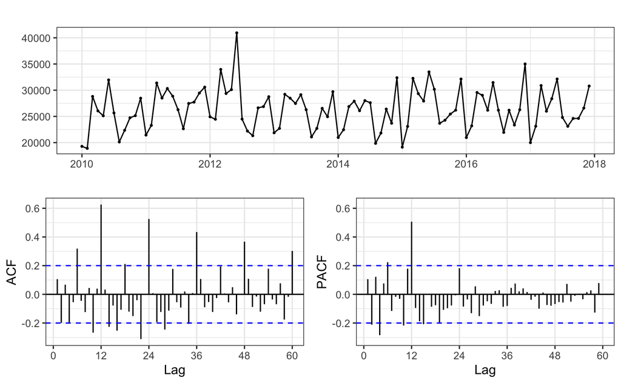

Die Reihe ist nicht stationär. Erst die zweifache Differenzierung bringt ein Ergebnis:

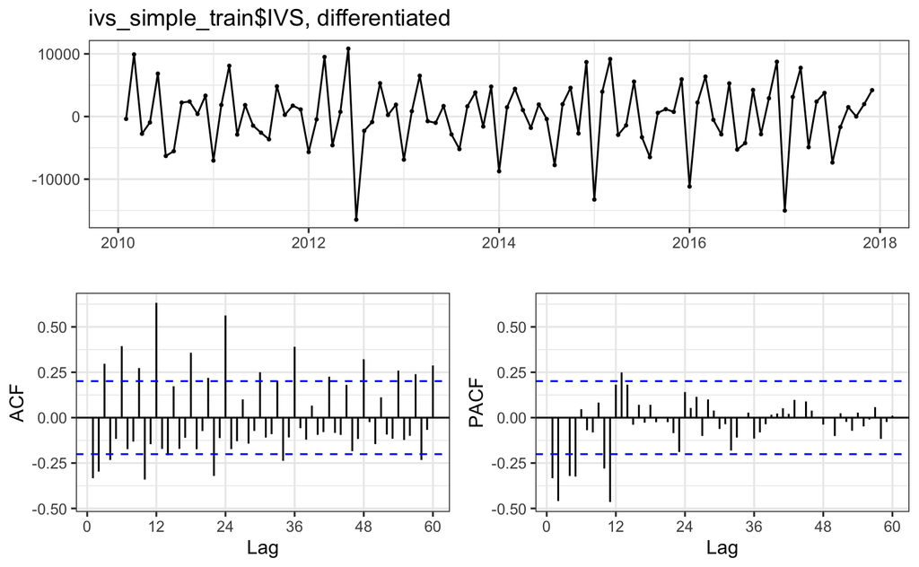

[figure not shown]

```
    Ljung-Box test

data:  Residuals from ARIMA(2,1,0)(0,1,1)[12]
Q* = 15.805, df = 16, p-value = 0.4667

Model df: 3.   Total lags used: 19
```

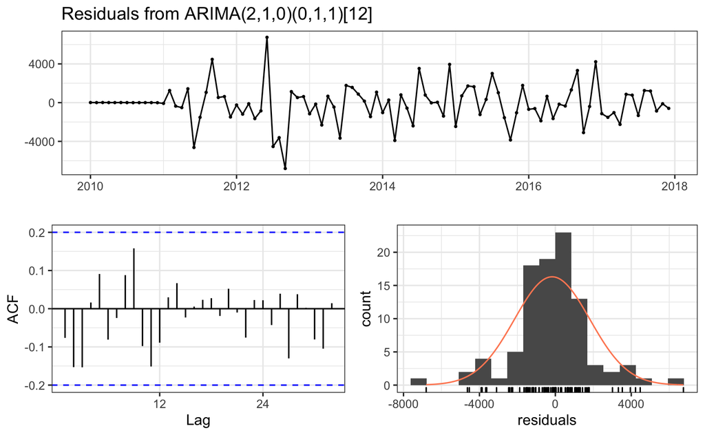

Die Residuen sehen wie weißes Rauschen aus und die Autokorrelationswerte der Residuen sind alle unbenklich. Mit dem Arima-Modell kann weitergearbeitet werden - Ziel ist ja die Prognose.

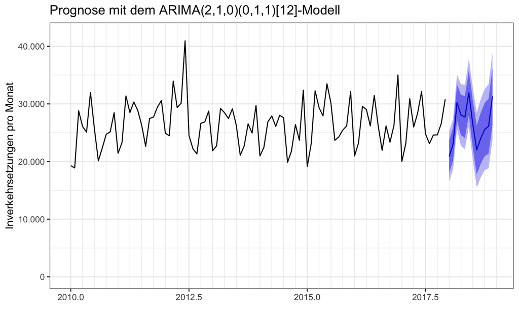

| mae | mape | mse | rmse |
| --- | --- | --- | --- |
| 1636.912 | 0.067755 | 4173531 | 2042.922 |

### Differenzierung der Antriebsart

Die Wiederholung der Analyse mit dem zusätzlichen Regressor zeigt ein völlig anderes Bild. Die Treibstoffarten “Anderer” und “Ohne Motor” spielen in der Analyse keine besondere Rolle. Zur besseren Übersichtlichkeit wurden sie ausgeschlossen.

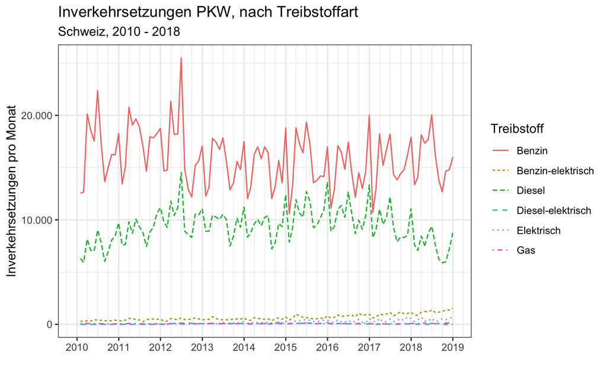

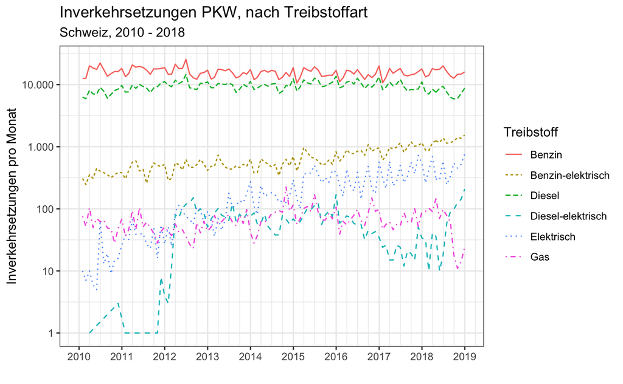

Die Abbildungen zeigen ein deutlich unterschiedliches Verhalten je Treibstoffart. Die Analyse der daher je Treibstoffart wiederholt.

### Lineare Modelle je Treibstoffart

#### Modelle berechnen und plotten

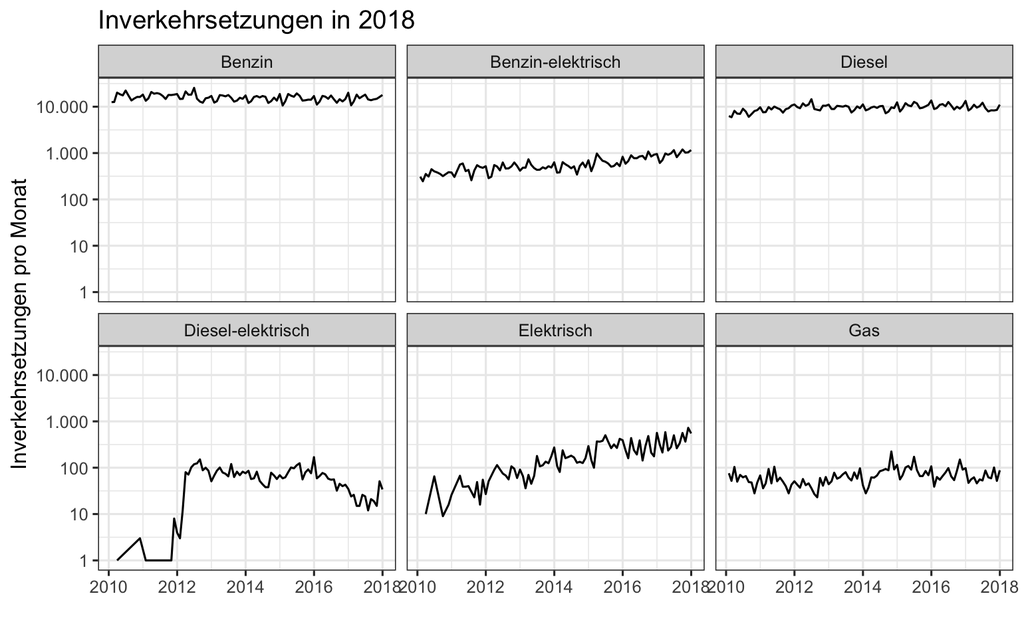

| Treibstoff | r.squared | adj.r.squared | sigma | statistic | p.value | df | logLik | AIC | BIC | deviance | df.residual |
| --- | --- | --- | --- | --- | --- | --- | --- | --- | --- | --- | --- |
| Diesel-elektrisch | 0.1084557 | -0.02044226 | 40.75398 | 0.8414075 | 6.081259e-01 | 13 | -485.1589 | 998.3177 | 1034.219 | 137853.61 | 83 |
| Gas | 0.2221313 | 0.10966841 | 28.53581 | 1.9751515 | 3.682583e-02 | 13 | -450.9451 | 929.8902 | 965.791 | 67586.28 | 83 |
| Diesel | 0.6262927 | 0.57226269 | 1066.94741 | 11.5915775 | 2.732497e-13 | 13 | -798.5992 | 1625.1984 | 1661.099 | 94485273.13 | 83 |
| Elektrisch | 0.7699016 | 0.73663439 | 84.01611 | 23.1429396 | 1.344409e-21 | 13 | -554.6106 | 1137.2211 | 1173.122 | 585872.67 | 83 |
| Benzin-elektrisch | 0.7779282 | 0.74582139 | 114.37420 | 24.2294102 | 3.239083e-22 | 13 | -584.2234 | 1196.4468 | 1232.348 | 1085760.89 | 83 |
| Benzin | 0.7855315 | 0.75452401 | 1332.62800 | 25.3336022 | 7.998356e-23 | 13 | -819.9449 | 1667.8898 | 1703.791 | 147399483.01 | 83 |

Die Modellmetriken zeigen einen nur mäßigen Erklärungsgehalt für Diesel, Diesel-elektrisch und Gas.

#### Performanceberechnung

Je Treibstoffart werden für das jeweilge Modell die Performance-Kennzahlen ermittelt.

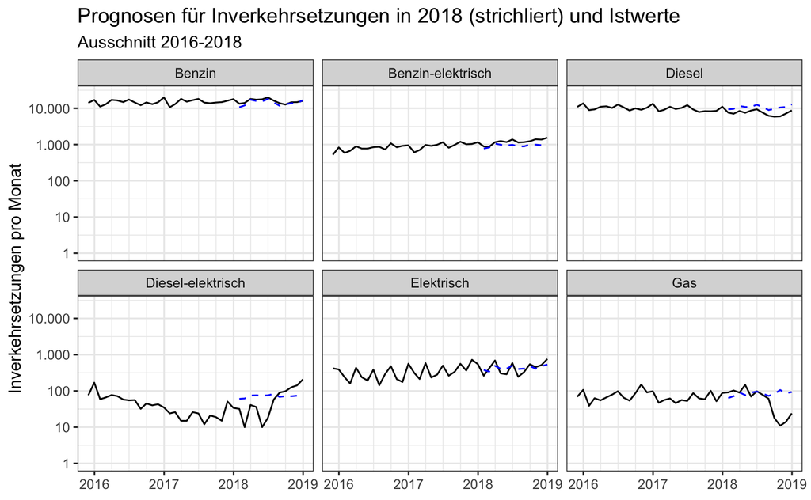

| Treibstoff | mae | mape | mse | rmse |
| --- | --- | --- | --- | --- |
| Benzin | 1457.41142 | 0.09365508 | 2680636.506 | 1637.26495 |
| Benzin-elektrisch | 265.01043 | 0.20678757 | 88245.112 | 297.06079 |
| Elektrisch | 109.78249 | 0.27526129 | 15288.263 | 123.64571 |
| Diesel | 3185.35889 | 0.43694110 | 10709765.603 | 3272.57782 |
| Diesel-elektrisch | 50.09039 | 1.67489083 | 3333.087 | 57.73289 |
| Gas | 39.26229 | 1.82759263 | 2535.273 | 50.35150 |

### ARIMA-Modelle je Treibstoffart

#### Modelle berechnen und plotten

Die eher enttäuschende Ergebnisse legen den Versuch nahe, je Treibstoffart mit ARIMA zu modellieren.

[output not shown]

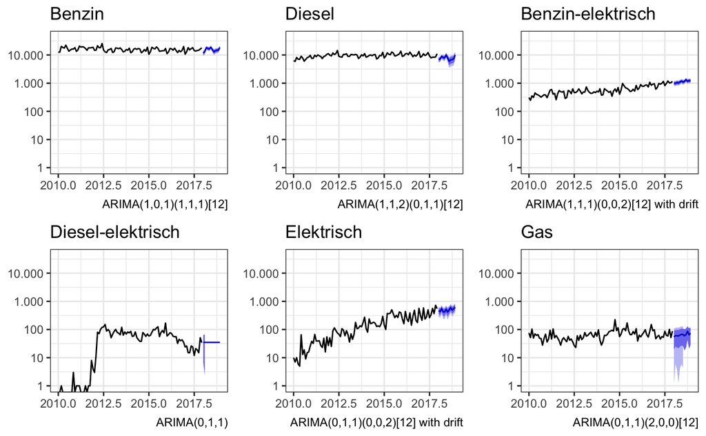

#### Performanceberechnung

Ist die Performance besser als bei linearen Modell?

| Treibstoff | mae | mape | mse | rmse |
| --- | --- | --- | --- | --- |
| Benzin | 907.68532 | 0.05968302 | 1293732.520 | 1137.42363 |
| Diesel | 555.22836 | 0.07492032 | 399764.764 | 632.26953 |
| Benzin-elektrisch | 139.71973 | 0.11198218 | 26917.029 | 164.06410 |
| Elektrisch | 106.82098 | 0.30125012 | 15076.808 | 122.78765 |
| Diesel-elektrisch | 49.10208 | 0.84669922 | 4901.463 | 70.01045 |
| Gas | 39.20016 | 1.46309737 | 2162.412 | 46.50174 |

### Quellen

Backhaus et al. (2018): *Multivariate Analysemethoden. Eine anwendungsorientierte Einführung*. 15 Aufl. Berlin. Heidelberg. [Springer-Verlag](https://www.springer.com/de/book/9783662566541).

Ilg, Markus; Baumeister, Alexander (2019): *Business Analytics im Marketing-Controlling - Eine Anwendungsfallstudie für den Automobildmarkt* in: Digitalisierung im Controlling. Hrsg. v. Keimer, I. und Egle U., S. xxx-yyy, Berlin: Springer.

Ruppert, David; Matteson, David S. (2015): Statistics and Data Analysis for Financial Engineering [Springer-Verlag](https://www.springer.com/de/book/9781493926138)